# Detecting outlier samples in PCA

Florian Privé

August 22, 2019

In this post, I present something I am currently investigating (feedback welcome!) and that I am implementing in my new [package {bigutilsr}](https://github.com/privefl/bigutilsr). This package can be used to detect outlier samples in Principal Component Analysis (PCA).

```r
remotes::install_github("privefl/bigutilsr")
```

```r
library(bigutilsr)
```

## A standard way to detect outliers

### Data

```r
X <- readRDS(system.file("testdata", "three-pops.rds", package = "bigutilsr"))
pca <- prcomp(X, scale. = TRUE, rank. = 10)
U <- pca$x
```

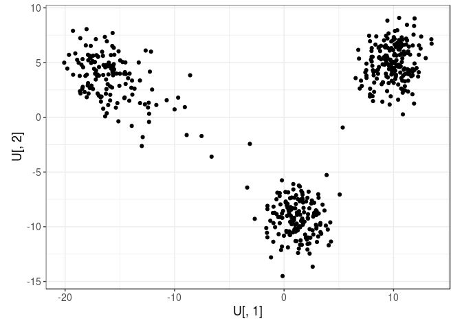

```r
library(ggplot2)
theme_set(bigstatsr::theme_bigstatsr(0.8))
qplot(U[, 1], U[, 2]) + coord_equal()
```

### Measuring outlierness

The standard way to detect outliers in genetics is the criterion of being “more than 6 standard deviations away from the mean”.

```r
apply(U, 2, function(x) which( abs(x - mean(x)) > (6 * sd(x)) ))
```

```
## integer(0)
```

Here, there is no outlier according to this criterion. Let us make some fake one.

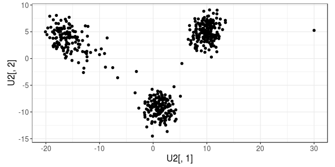

```r
U2 <- U
U2[1, 1] <- 30
qplot(U2[, 1], U2[, 2]) + coord_equal()
```

```r
apply(U2, 2, function(x) which( abs(x - mean(x)) > (6 * sd(x)) ))
```

```
## integer(0)
```

Still not an outlier..

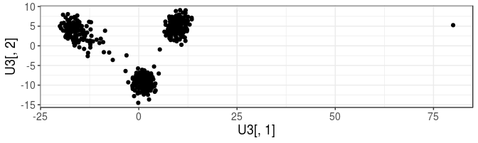

```r
U3 <- U2
U3[1, 1] <- 80
qplot(U3[, 1], U3[, 2]) + coord_equal()
```

```r
library(magrittr)
apply(U3, 2, function(x) which( abs(x - mean(x)) > (6 * sd(x)) )) %>%
  Reduce(union, .)
```

```
## [1] 1
```

Now, the first sample is considered as an outlier by this criterion.

### A more robust variation

Note that you might want to use `median()` instead of `mean()` and `mad()` instead of `sd()` because they are more robust estimators. This becomes

```r
ind.out <- apply(U3, 2, function(x) which( (abs(x - median(x)) / mad(x)) > 6 )) %>%
  Reduce(union, .) %>%
  print()
```

```
## [1]   1 516
```

We get a new outlier.

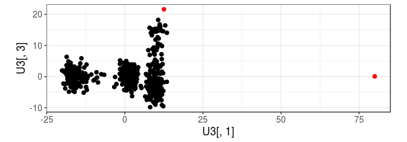

```r
col <- rep("black", nrow(U3)); col[ind.out] <- "red"
qplot(U3[, 1], U3[, 3], color = I(col), size = I(2)) + coord_equal()
```

### A continuous view of this criterion

This criterion flag an outlier if it is an outlier for at least one principal component (PC). This corresponds to using the `max()` (infinite) distance (in terms of number of standard deviations) from the mean.

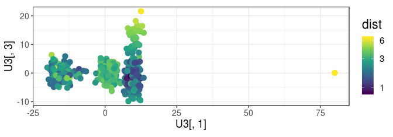

```r
dist <- apply(U3, 2, function(x) abs(x - median(x)) / mad(x)) %>%
  apply(1, max)
qplot(U3[, 1], U3[, 3], color = dist, size = I(3)) + coord_equal() +
  scale_color_viridis_c(trans = "log", breaks = c(1, 3, 6))
```

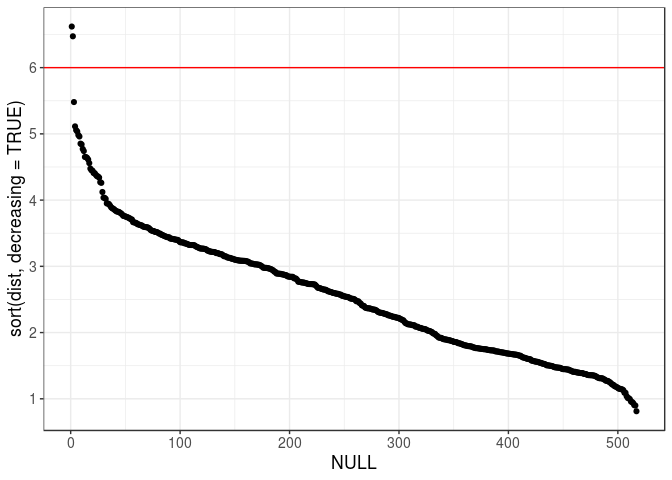

```r
qplot(y = sort(dist, decreasing = TRUE)) +
  geom_hline(yintercept = 6, color = "red")
```

## Investigating two other criteria of outlierness

### Robust Mahalanobis distance

Instead of using the infinite distance, Mahalanobis distance is a multivariate distance based on all variables (PCs here) at once. We use a robust version of this distance, which is implemented in packages {robust} and {robustbase} (Gnanadesikan and Kettenring 1972, Yohai and Zamar (1988), Maronna and Zamar (2002), Todorov, Filzmoser, and others (2009)) and that is reexported in {bigutilsr}.

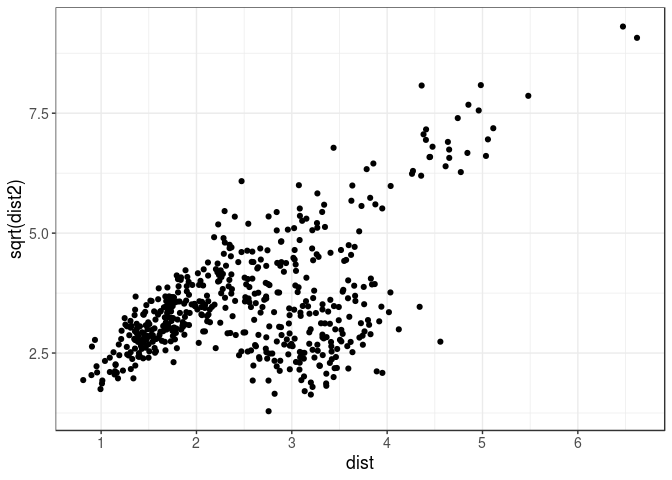

```r
dist2 <- covRob(U3, estim = "pairwiseGK")$dist
qplot(dist, sqrt(dist2))
```

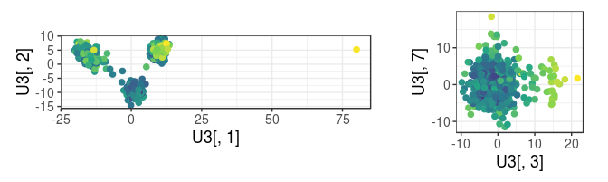

```r
cowplot::plot_grid(
  qplot(U3[, 1], U3[, 2], color = dist2, size = I(2)) + coord_equal() +
    scale_color_viridis_c(trans = "log", breaks = NULL),
  qplot(U3[, 3], U3[, 7], color = dist2, size = I(2)) + coord_equal() +
    scale_color_viridis_c(trans = "log", breaks = NULL),
  rel_widths = c(0.7, 0.4), scale = 0.95
)
```

This new criterion provides similar results for this data. These robust Mahalanobis distances are approximately Chi-square distributed, which enables deriving p-values of outlierness.

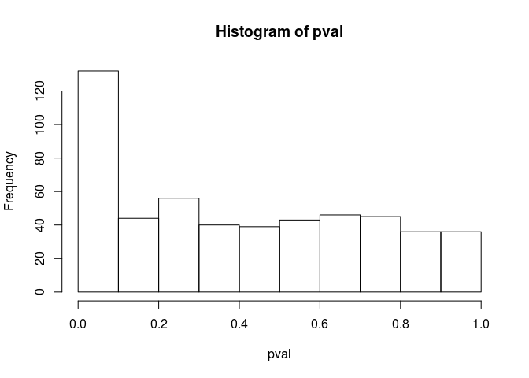

```r
pval <- pchisq(dist2, df = 10, lower.tail = FALSE)
hist(pval)
```

```r
is.out <- (pval < (0.05 / length(dist2)))  # Bonferroni correction
sum(is.out)
```

```
## [1] 33
```

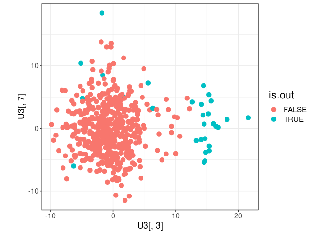

```r
qplot(U3[, 3], U3[, 7], color = is.out, size = I(3)) + coord_equal()
```

### Local Outlier Factor (LOF)

LOF statistic (Breunig et al. 2000) has been cited more than 4000 times. Instead of computing a distance from the center, it uses some local density of points. We make use of the fast K nearest neighbours implementation of R package {nabor} (Elseberg et al. 2012) to implement this statistic efficiently in {bigutilsr}.

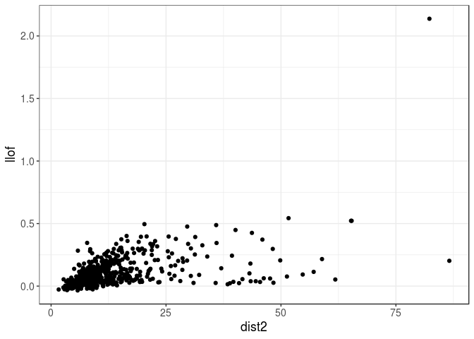

```r
llof <- LOF(U3)  # log(LOF) by default
qplot(dist2, llof)
```

The fake outlier that we introduced is now clearly an outlier. The other points, not so much.

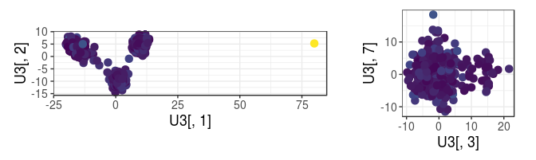

```r
cowplot::plot_grid(
  qplot(U3[, 1], U3[, 2], color = llof, size = I(3)) + coord_equal() +
    scale_color_viridis_c(breaks = NULL),
  qplot(U3[, 3], U3[, 7], color = llof, size = I(3)) + coord_equal() +
    scale_color_viridis_c(breaks = NULL),
  rel_widths = c(0.7, 0.4), scale = 0.95
)
```

## Choosing the threshold of being an outlier

Threshold of `6` for the first criterion presented here may appear arbitrary. If the data you have is normally distributed, each sample (for each PC) has a probability of `2 * pnorm(-6)` (2e-9) of being considered as an outlier by this criterion.

Accounting for multiple testing, *for 10K samples and 10 PCs*, there is a chance of `1 - (1 - 2 * pnorm(-6))^100e3` (2e-4) of detecting at least one outlier. If choosing `5` as threshold, there is 5.6% chance of detecting at least one outlier when PCs are normally distributed. If choosing `3` instead, this probability is 1.

### Tukey’s rule

Tukey’s rule (Tukey 1977) is a standard rule for detecting outliers. Here, we will apply it on the previously computed statistics. Note that we could use it directly on PCs, which is not much different from the robust version of the first criterion we introduced.

```r
x <- rnorm(10000)
(tukey_up  <- quantile(x, 0.75) + 1.5 * IQR(x))
```

```
##      75%
## 2.692865
```

```r
(tukey_low <- quantile(x, 0.25) - 1.5 * IQR(x))
```

```
##       25%
## -2.655962
```

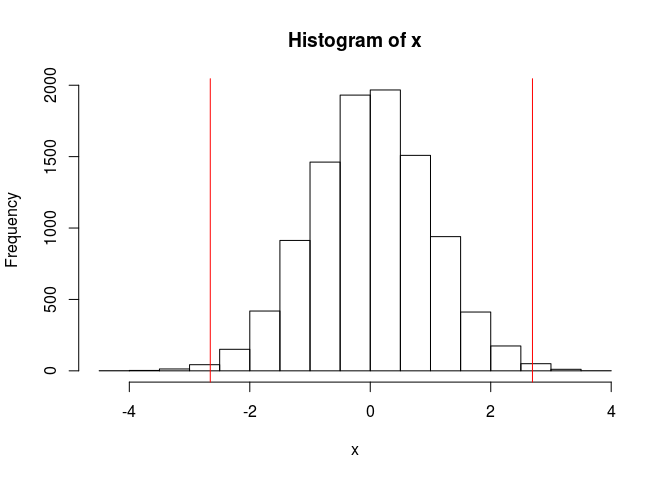

```r
hist(x); abline(v = c(tukey_low, tukey_up), col = "red")
```

```r
mean(x < tukey_low | x > tukey_up)
```

```
## [1] 0.007
```

where `IQR(x)` is equal to `quantile(x, 0.75) - quantile(x, 0.25)` (the InterQuartile Range).

However, there are two pitfalls when using Tukey’s rule:

1. Tukey’s rule assumes a normally distributed sample. When the data is skewed, it does not work that well.

   ```r
   x <- rchisq(10000, df = 5)
   (tukey_up  <- quantile(x, 0.75) + 1.5 * IQR(x))
   ```

   ```
   ##      75%
   ## 12.64001
   ```

   ```r
   (tukey_low <- quantile(x, 0.25) - 1.5 * IQR(x))
   ```

   ```
   ##       25%
   ## -3.324605
   ```

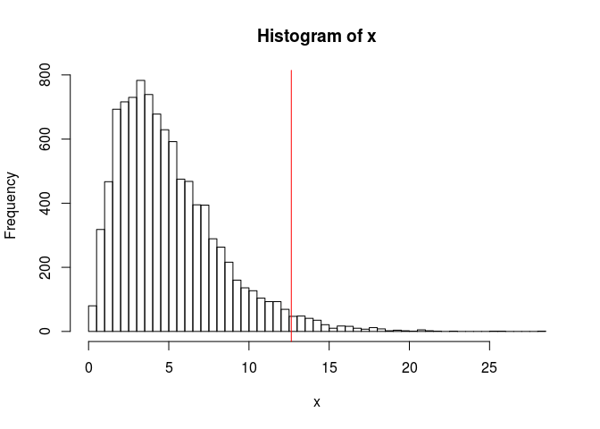

   ```r
   hist(x, "FD"); abline(v = c(tukey_low, tukey_up), col = "red")
   ```

   ```r
   mean(x < tukey_low | x > tukey_up)
   ```

   ```
   ## [1] 0.0278
   ```

   To solve the problem of skewness, the medcouple (mc) has been introduced (Hubert and Vandervieren 2008) and is implemented in `robustbase::adjboxStats()`.
2. Tukey’s rule uses a fixed coefficient (`1.5`) that does not account for multiple testing, which means that for large samples, you will almost always get some outliers if using `1.5`.

To solve these two issues, we implemented `tukey_mc_up()` that accounts both for skewness and multiple testing by default.

```r
x <- rchisq(10000, df = 5)
(tukey_up  <- quantile(x, 0.75) + 1.5 * IQR(x))
```

```
##      75%
## 12.58554
```

```r
hist(x, "FD"); abline(v = tukey_up, col = "red")
abline(v = print(tukey_mc_up(x, coef = 1.5)), col = "blue")
```

```
## [1] 17.27713
```

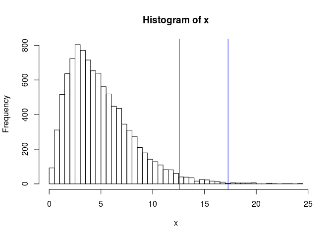

```
## [1] 26.39443
```

```r
abline(v = print(tukey_mc_up(x)), col = "green")  # accounts for multiple testing
```

Applying this corrected Tukey’s rule to our statistics:

```r
tukey_mc_up(dist)
```

```
## [1] 6.406337
```

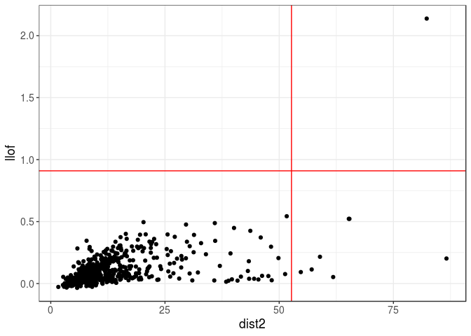

```r
qplot(dist2, llof) +
  geom_vline(xintercept = tukey_mc_up(dist2), color = "red") +
  geom_hline(yintercept = tukey_mc_up(llof),  color = "red")
```

### Histogram’s gap

This rule I come up with assumes that the “normal” data is somewhat grouped and the outliers have some gap (in the histogram, there is a bin with no value in it) with the rest of the data.

For example, for `dist`, there is a gap just before 6, and we can derive an algorithm to detect this:

```r
hist(dist, breaks = nclass.scottRob)
str(hist_out(dist))
```

```
## List of 2
##  $ x  : num [1:515] 2.08 2.06 1.74 1.86 2.04 ...
##  $ lim: num [1:2] -Inf 5.75
```

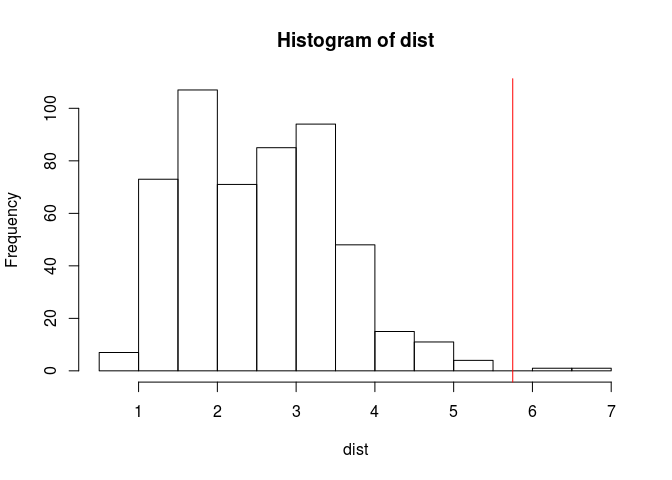

```r
abline(v = hist_out(dist)$lim[2], col = "red")
```

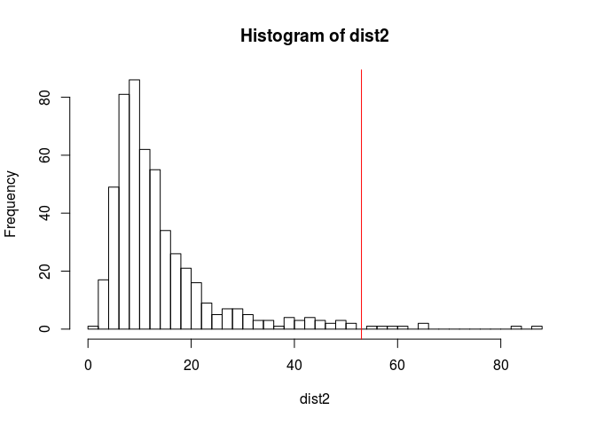

```r
hist(dist2, breaks = nclass.scottRob)
abline(v = hist_out(dist2)$lim[2], col = "red")
```

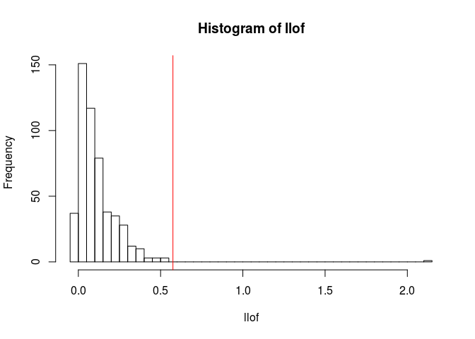

```r
hist(llof, breaks = nclass.scottRob)
abline(v = hist_out(llof)$lim[2], col = "red")
```

This criterion is convenient because it does not assume any distribution of the data, just that it is compact and that the outliers are not in the pack.

It could be used in other contexts, e.g. choosing the number of outlier principal components:

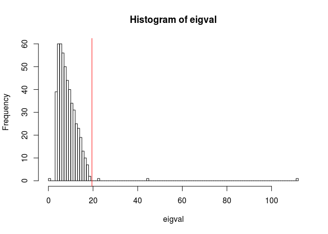

```r
eigval <- pca$sdev^2
hist(eigval, breaks = "FD")  # "FD" gives a bit more bins than scottRob
abline(v = hist_out(eigval, breaks = "FD")$lim[2], col = "red")
```

```r
sum(eigval > hist_out(eigval, breaks = "FD")$lim[2])
```

```
## [1] 3
```

```r
pca_nspike(eigval)  # directly implemented in {bigutilsr}
```

```
## [1] 3
```

Note the possible use of bootstrap to make `hist_out()` and `pca_nspike()` more robust.

## Conclusion

Outlier detection is not an easy task, especially if you want the criterion of outlierness to be robust to several factors such as sample size and distribution of the data. Moreover, there is always some threshold to choose to separate outliers from non-ouliers.

With one small example, we have seen several statistics to compute some degree of outlierness, and several ways to decide the threshold of being an outlier according to those statistics.

I have been investigating outlier detection in the past weeks. Any feedback and further input on this would be great.

## References

Breunig, Markus M, Hans-Peter Kriegel, Raymond T Ng, and Jörg Sander. 2000. “LOF: Identifying Density-Based Local Outliers.” In *ACM Sigmod Record*, 29:93–104. 2. ACM.

Elseberg, Jan, Stéphane Magnenat, Roland Siegwart, and Andreas Nüchter. 2012. “Comparison of Nearest-Neighbor-Search Strategies and Implementations for Efficient Shape Registration.” *Journal of Software Engineering for Robotics* 3 (1): 2–12.

Gnanadesikan, Ramanathan, and John R Kettenring. 1972. “Robust Estimates, Residuals, and Outlier Detection with Multiresponse Data.” *Biometrics*. JSTOR, 81–124.

Hubert, Mia, and Ellen Vandervieren. 2008. “An Adjusted Boxplot for Skewed Distributions.” *Computational Statistics & Data Analysis* 52 (12). Elsevier: 5186–5201.

Maronna, Ricardo A, and Ruben H Zamar. 2002. “Robust Estimates of Location and Dispersion for High-Dimensional Datasets.” *Technometrics* 44 (4). Taylor & Francis: 307–17.

Todorov, Valentin, Peter Filzmoser, and others. 2009. “An Object-Oriented Framework for Robust Multivariate Analysis.” Citeseer.

Tukey, John W. 1977. *Exploratory Data Analysis*. Addison-Wesley.

Yohai, Victor J, and Ruben H Zamar. 1988. “High Breakdown-Point Estimates of Regression by Means of the Minimization of an Efficient Scale.” *Journal of the American Statistical Association* 83 (402). Taylor & Francis: 406–13.